## HW7_Clustering_201511646 나여영

> 1. In this example, we have distances between ten American cities based on the flying mileages between them. The objective is to see if we can define clusters of these cities based on the distances.

```r
Atlanta<-c(0,587,1212,701,1936,604,748,2139,2182,543)
Chicago<-c(587,0,920,940,1745,1188,713,1858,1737,597)
Denver<-c(1212,920,0,879,831,1726,1631,949,1021,1494)
Houston<-c(701,940,879,0,1374,968,1420,1645,1891,1220)
LA<-c(1936,1745,831,1374,0,2339,2451,347,959,2300)
Miami<-c(604,1188,1726,968,2339,0,1092,2594,2734,923)
Newyork<-c(748,713,1631,1420,2451,1092,0,2571,2408,205)
Sanfrancisco<-c(2139,1858,949,1645,347,2594,2571,0,678,2442)
Seattle<-c(2182,1737,1021,1891,959,2734,2408,678,0,2329)
WashingtonDC<-c(543,597,1494,1220,2300,923,205,2442,2329,0)
```

다음은 대칭행렬이 맞는지 확인하는 과정이다

```r
cities<-matrix(c(Atlanta,Chicago,Denver, Houston,LA, Miami, Newyork,Sanfrancisco, Seattle, WashingtonDC),10,byrow=T)
cities
```

```
##       [,1] [,2] [,3] [,4] [,5] [,6] [,7] [,8] [,9] [,10]
##  [1,]    0  587 1212  701 1936  604  748 2139 2182   543
##  [2,]  587    0  920  940 1745 1188  713 1858 1737   597
##  [3,] 1212  920    0  879  831 1726 1631  949 1021  1494
##  [4,]  701  940  879    0 1374  968 1420 1645 1891  1220
##  [5,] 1936 1745  831 1374    0 2339 2451  347  959  2300
##  [6,]  604 1188 1726  968 2339    0 1092 2594 2734   923
##  [7,]  748  713 1631 1420 2451 1092    0 2571 2408   205
##  [8,] 2139 1858  949 1645  347 2594 2571    0  678  2442
##  [9,] 2182 1737 1021 1891  959 2734 2408  678    0  2329
## [10,]  543  597 1494 1220 2300  923  205 2442 2329     0
```

```r
Tcities=t(cities)

library(dplyr)
all_equal(cities, Tcities)
```

```
## [1] TRUE
```

맞는지 확인했으므로 그 후 scatter plot을 확인해 데이터의 분포를 본다.

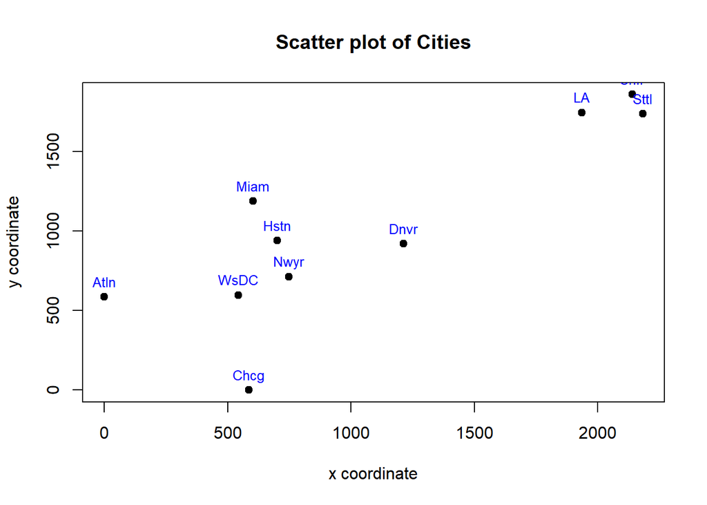

```r
colnames(cities)<-c("Atlanta","Chicago","Denver", "Houston","LA", "Miami", "Newyork","Sanfrancisco", "Seattle", "WashingtonDC")
rownames(cities)<-c("Atlanta","Chicago","Denver", "Houston","LA", "Miami", "Newyork","Sanfrancisco", "Seattle", "WashingtonDC")

plot(cities,pch = 19, xlab = c("x coordinate"), ylab = c("y coordinate"),main = "Scatter plot of Cities")
text(cities, labels = abbreviate(colnames(cities)), cex = 0.8, pos = 3, col = "blue") # pos=1 : at the bottom
```

> 1. Do the cluster analysis using (1) single linkage, (2) average linkage and (3) the centroid method.

(1)single linkage

```r
hc1_cities<-hclust(dist(cities, method="euclidian")^2, method="single")
hc1_cities
```

```
##
## Call:
## hclust(d = dist(cities, method = "euclidian")^2, method = "single")
##
## Cluster method   : single
## Distance         : euclidean
## Number of objects: 10
```

```r
rev(hc1_cities) #height : 군집간 거리 / merge: 병합순
```

```
## $dist.method
## [1] "euclidean"
##
## $call
## hclust(d = dist(cities, method = "euclidian")^2, method = "single")
##
## $method
## [1] "single"
##
## $labels
##  [1] "Atlanta"      "Chicago"      "Denver"       "Houston"
##  [5] "LA"           "Miami"        "Newyork"      "Sanfrancisco"
##  [9] "Seattle"      "WashingtonDC"
##
## $order
##  [1]  9  5  8  3  4  6  7 10  1  2
##
## $height
## [1]  272544  560711 1435040 1490187 1581207 2363192 2905270 4037129 4895001
##
## $merge
##       [,1] [,2]
##  [1,]   -7  -10
##  [2,]   -5   -8
##  [3,]   -9    2
##  [4,]   -1   -2
##  [5,]    1    4
##  [6,]   -6    5
##  [7,]   -4    6
##  [8,]   -3    7
##  [9,]    3    8
```

2. average linkage

```r
hc2_cities<-hclust(dist(cities, method="euclidian")^2, method="average")
hc2_cities
```

```
##
## Call:
## hclust(d = dist(cities, method = "euclidian")^2, method = "average")
##
## Cluster method   : average
## Distance         : euclidean
## Number of objects: 10
```

```r
rev(hc2_cities)
```

```
## $dist.method
## [1] "euclidean"
##
## $call
## hclust(d = dist(cities, method = "euclidian")^2, method = "average")
##
## $method
## [1] "average"
##
## $labels
##  [1] "Atlanta"      "Chicago"      "Denver"       "Houston"
##  [5] "LA"           "Miami"        "Newyork"      "Sanfrancisco"
##  [9] "Seattle"      "WashingtonDC"
##
## $order
##  [1]  9  5  8  6  7 10  1  2  3  4
##
## $height
## [1]   272544   560711  1490187  1953324  2528224  3651036  4037129  8604104
## [9] 21933100
##
## $merge
##       [,1] [,2]
##  [1,]   -7  -10
##  [2,]   -5   -8
##  [3,]   -1   -2
##  [4,]   -9    2
##  [5,]    1    3
##  [6,]   -6    5
##  [7,]   -3   -4
##  [8,]    6    7
##  [9,]    4    8
```

3. the centroid method.

```r
hc3_cities<-hclust(dist(cities, method="euclidian")^2, method="centroid")
hc3_cities
```

```
##
## Call:
## hclust(d = dist(cities, method = "euclidian")^2, method = "centroid")
##
## Cluster method   : centroid
## Distance         : euclidean
## Number of objects: 10
```

```r
rev(hc3_cities)
```

```
## $dist.method
## [1] "euclidean"
##
## $call
## hclust(d = dist(cities, method = "euclidian")^2, method = "centroid")
##
## $method
## [1] "centroid"
##
## $labels
##  [1] "Atlanta"      "Chicago"      "Denver"       "Houston"
##  [5] "LA"           "Miami"        "Newyork"      "Sanfrancisco"
##  [9] "Seattle"      "WashingtonDC"
##
## $order
##  [1]  9  5  8  6  7 10  1  2  3  4
##
## $height
## [1]   272544   560711  1490187  1813146  2087541  2908810  4037129  6535631
## [9] 19057993
##
## $merge
##       [,1] [,2]
##  [1,]   -7  -10
##  [2,]   -5   -8
##  [3,]   -1   -2
##  [4,]   -9    2
##  [5,]    1    3
##  [6,]   -6    5
##  [7,]   -3   -4
##  [8,]    6    7
##  [9,]    4    8
```

> 2. For each method, (a) determine the number of clusters suggested by dendrogram, the CCC method and the Hotelling T-squared method. Show the assignment of cities to the clusters.
1. dendrogram

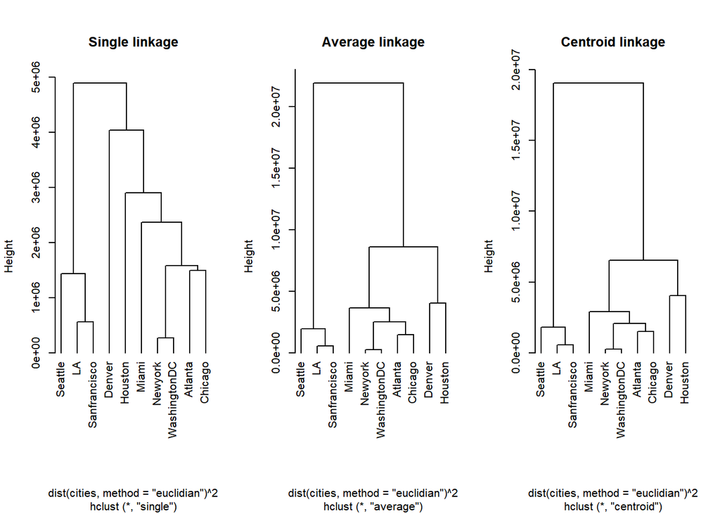

```r
my_par = par(no.readonly = TRUE)
par(oma = c(0, 0, 1, 0))
par(mfrow=c(1,3))
plot(hc1_cities, hang = -1, main="Single linkage") # hang = -1 : line from the bottom
plot(hc2_cities, hang=-1, main="Average linkage")
plot(hc3_cities, hang=-1, main="Centroid linkage")
```

> 결론 : 군집 개수를 두개로 했을 때 Seattle, LA, Sanfrancisco 를 한그룹 / 나머지를 한그룹 이렇게 분류할 수 있다. 하지만 3개 이상부터는 방법에 따라 다르게 묶이게 된다.